# StockResearch

Gabriel Foix

2021-03-08

Buy Quality at the a good momentum and get rid of the fishy stocks on time. That's all.

### Define candidates

Download all info needed applying the following filters:

### Factor 1: Quality

1. Healthy debts: A company shoud generate cash in order to repay its debt. The **Free Cash Flow to Debt** ratio is a good indicator of how quick a company pays back its debt. The lower this ratio the better.

FCF2D = $\frac{Debt}{Free Cash Flow}$

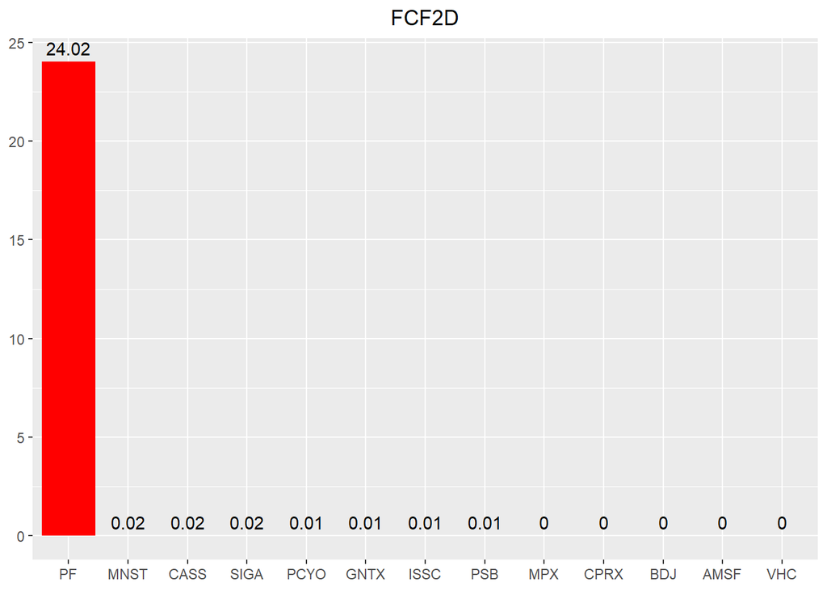

2. Profitability: ROA

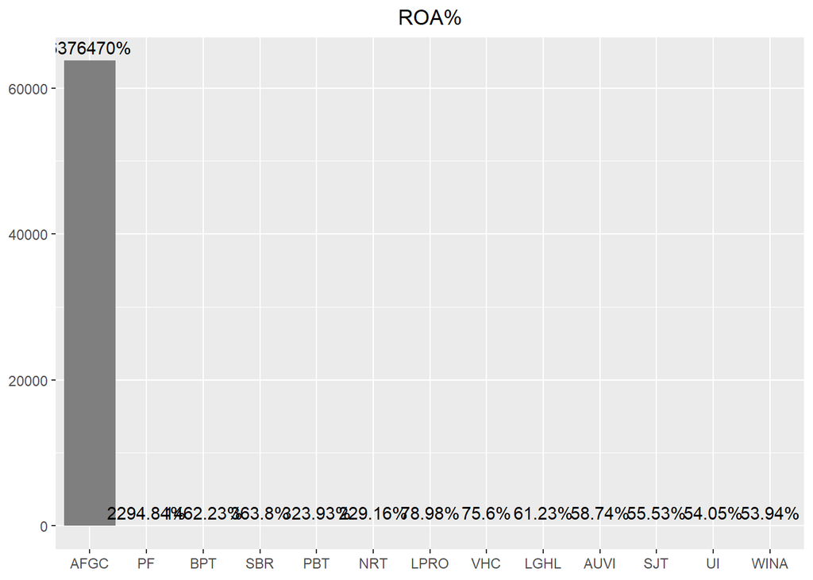

3. High Margin: We look for companies that generate free cash flow compare to its price. The **Free Cash Flow to Entreprise Value** ratio tells us how many years of cash flow would be needed to the return the 100% of the investment. Again, the lower, the better. Values bellow 1 would mean "free lunch".

FCF2EV = $\frac{EV}{Free Cash Flow}$

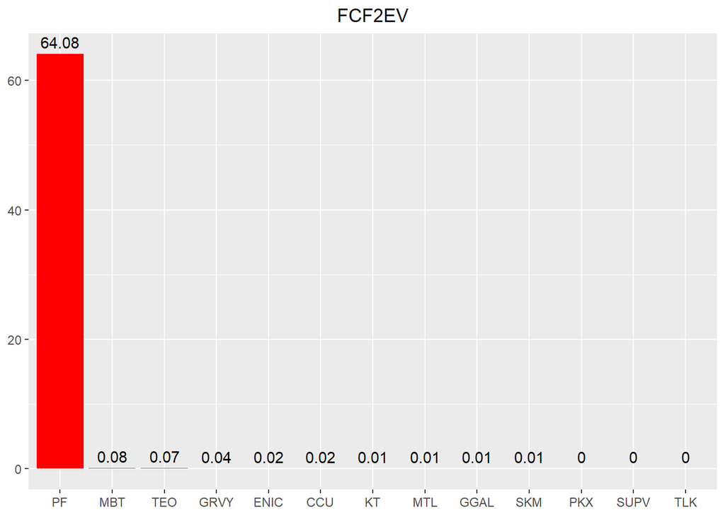

#### Download Historical Data

Download only stocks not filtered previously

### Value touch

Filter out stocks with PER > 40

Report Candidates

Filter Summary

| Filter | NStocks |
| --- | --- |
| Initial | 9285 |
| ROA | 2786 |
| FCF | 2786 |
| Hist1Y | 2737 |
| PER | 2737 |

### Factor 2: Momentum

Don't hold onto a stock simply because it is high quality. So called quality stocks have cycles too. Stan Weinstein (page 177)

Generic Intermediate-Term Momentum Based on Gray-Vogel (page 80)

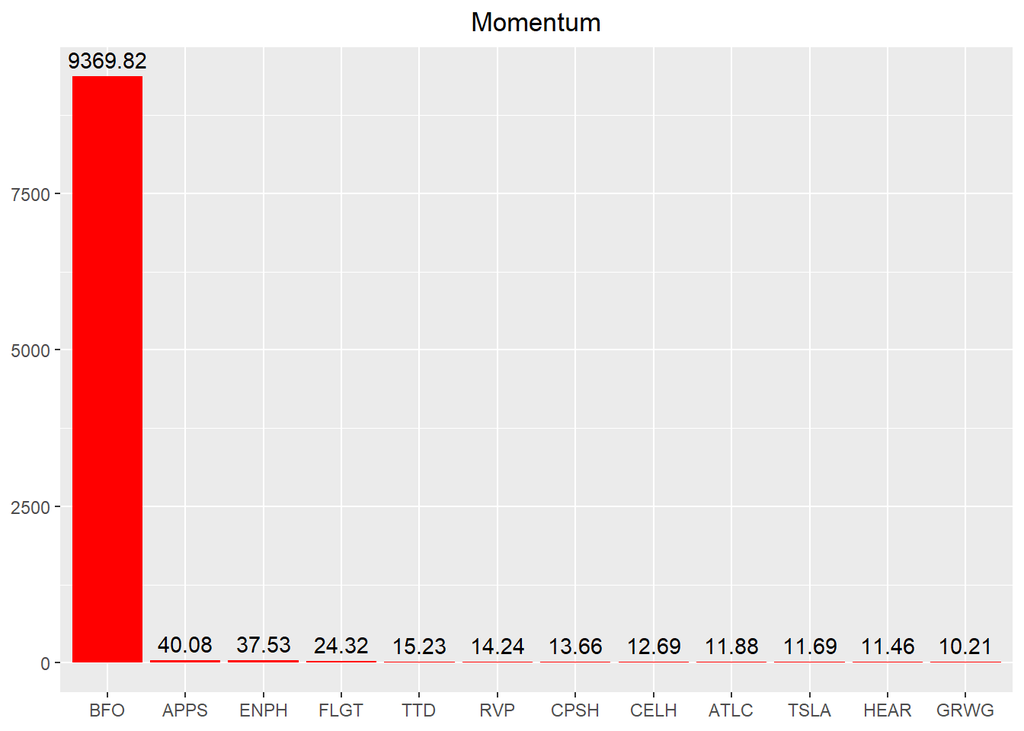

### Factor 3: Timing Signal

Sell Signal - Pr < 1% SMA 30 weeks and slope negative (< -0.2)  
Buy Signal - 109% * SMA30 < Pr > SMA 30 and slope positive (> 0.2)  
Hold Signal - Neither Buy nor Sell

#### Calc Market Cap

Using free float shares

### Summary

Summary

| Ticker | Signal | Quality | Momentum | Final_rank | PER | MCap |
| --- | --- | --- | --- | --- | --- | --- |
| FLGT | HOLD | 2780.0 | 2734 | 2783.0 | 1.061279e+01 | 1.291626e+09 |
| HEAR | BUY | 2685.0 | 2727 | 2777.0 | 9.945148e+00 | 3.582540e+08 |
| RCII | HOLD | 2674.0 | 2706 | 2774.0 | 1.579625e+01 | 3.002888e+09 |
| APT | SELL | 2681.0 | 2657 | 2771.0 | 8.299180e+00 | 1.396940e+08 |
| FFHL | HOLD | 2714.0 | 2620 | 2770.0 | -6.999255e+00 | 1.170149e+07 |
| HIBB | HOLD | 2761.5 | 2533 | 2767.0 | 1.486468e+01 | 1.057295e+09 |
| OIIM | BUY | 2587.0 | 2689 | 2766.0 | 3.140845e+01 | 1.352039e+08 |
| MHH | SELL | 2751.0 | 2513 | 2765.0 | 2.131325e+01 | 6.952968e+07 |
| REGI | HOLD | 2559.0 | 2697 | 2764.0 | 2.699638e+01 | 2.858477e+09 |
| QDEL | SELL | 2635.0 | 2595 | 2762.0 | 8.198290e+00 | 5.853352e+09 |
| YETI | HOLD | 2571.0 | 2650 | 2761.0 | 3.846328e+01 | 5.576658e+09 |
| SPWH | HOLD | 2565.0 | 2654 | 2760.0 | 1.047619e+01 | 6.809386e+08 |
| LINC | HOLD | 2630.0 | 2565 | 2757.0 | 3.993288e+00 | 8.997193e+07 |
| IDT | HOLD | 2618.0 | 2564 | 2755.0 | 1.224169e+01 | 2.011423e+08 |
| COE | HOLD | 2661.0 | 2520 | 2754.0 | -7.185028e+00 | 1.587193e+08 |
| LOGI | BUY | 2595.0 | 2584 | 2753.0 | 1.663928e+01 | 1.527169e+10 |
| DECK | HOLD | 2549.0 | 2627 | 2751.0 | 2.462094e+01 | 8.856427e+09 |
| LAKE | HOLD | 2694.0 | 2478 | 2750.0 | 8.272237e+00 | 2.056377e+08 |
| MED | HOLD | 2589.0 | 2568 | 2748.0 | 2.703111e+01 | 2.390703e+09 |
| SID | HOLD | 2680.0 | 2467 | 2745.0 | 8.715084e+00 | 4.008588e+09 |
| ONEW | HOLD | 2641.0 | 2501 | 2743.0 | 1.520343e-01 | 3.445753e+08 |
| LFVN | SELL | 2663.5 | 2477 | 2742.0 | 1.186250e+01 | 1.101434e+08 |
| RCKY | HOLD | 2746.0 | 2387 | 2741.0 | 1.591259e+01 | 3.047917e+08 |
| MOH | BUY | 2591.0 | 2527 | 2739.0 | 1.934461e+01 | 1.183662e+10 |
| LEU | HOLD | 2394.0 | 2703 | 2737.0 | 8.416389e+00 | 1.897464e+08 |
| WSM | HOLD | 2558.0 | 2537 | 2735.0 | 1.928582e+01 | 9.971632e+09 |
| VHC | BUY | 2745.0 | 2343 | 2734.0 | 1.472577e+00 | 3.693484e+08 |
| DHT | BUY | 2665.0 | 2403 | 2733.0 | 3.546584e+00 | 8.115711e+08 |
| VCTR | HOLD | 2766.0 | 2288 | 2731.0 | 8.680556e+00 | 1.917683e+08 |
| HZO | HOLD | 2613.0 | 2439 | 2729.5 | 1.286608e+01 | 1.045960e+09 |

[output cut: 1970 more lines]

Save output in template